# Nebraska and penalties – the story that wasn’t.

A frequent question in Nebraska press conferences during the last season was the number of penalties the team had been piling up. It’s easy to see why: The team was at one point dead last in the FBS in the number of penalty yards per game. Worst in major college football. The headlines write themselves.

The problem? It’s almost meaningless to the team’s success or failure.

```r
library(tidyverse)
library(ggrepel)
```

Loading the data

```r
penalties <- read_csv("~/Dropbox/SPMC350-Data-Literacy-and-Analytics-in-Sports/Data/Penalties.csv")
scoringoffense <- read_csv("~/Dropbox/SPMC350-Data-Literacy-and-Analytics-in-Sports/Data/ScoringOffense.csv")
offensivethirddowns <- read_csv("~/Dropbox/SPMC350-Data-Literacy-and-Analytics-in-Sports/Data/ThirdDownConversions.csv")
scoringdefense <- read_csv("~/Dropbox/SPMC350-Data-Literacy-and-Analytics-in-Sports/Data/ScoringDefense.csv")
defensivethirddowns <- read_csv("~/Dropbox/SPMC350-Data-Literacy-and-Analytics-in-Sports/Data/OpponentThirdDown.csv")
```

Creating some filtered examples to illustrate the point.

```r
nu <- penalties %>% filter(Name == "Nebraska") %>% filter(Year == 2018)
fbs <- penalties %>% filter(Year == 2018)
osu <- penalties %>% filter(Name == "Ohio State") %>% filter(Year == 2018)
```

At the point this data was captured, Nebraska was winless and people were looking for answers. But does penalties make you a bad team. Not unless then-undefeated Ohio State was bad. Here’s a bar chart to put things in context.

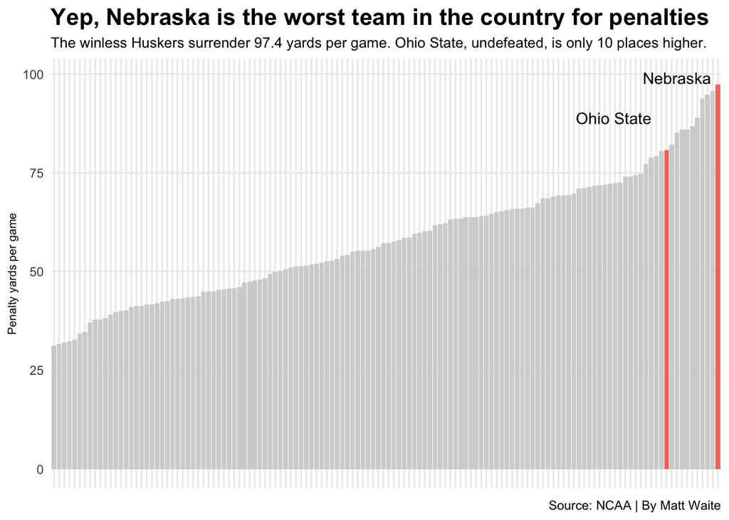

```r
ggplot() + geom_bar(data=fbs, aes(x=reorder(Name, `Yards/G`), weight=`Yards/G`), fill="light grey") + geom_bar(data=nu, aes(x=reorder(Name, `Yards/G`), weight=`Yards/G`, fill="red")) + geom_bar(data=osu, aes(x=reorder(Name, `Yards/G`), weight=`Yards/G`, fill="red")) + labs(x="None", y="Penalty yards per game", title="Yep, Nebraska is the worst team in the country for penalties", subtitle="The winless Huskers surrender 97.4 yards per game. Ohio State, undefeated, is only 10 places higher.", caption="Source: NCAA | By Matt Waite") + theme_minimal() + theme(axis.title.x=element_blank(), axis.text.x=element_blank(), axis.ticks.x=element_blank(), plot.title = element_text(size = 16, face = "bold"), axis.title = element_text(size = 8), plot.subtitle = element_text(size=10), panel.grid.minor = element_blank()) + guides(fill=FALSE) + geom_text(data=nu, aes(x=Name, y=99, label="Nebraska", hjust = 1.1)) + geom_text(data=osu, aes(x=Name, y=99, label="Ohio State", hjust = 1.2, vjust=4)) + ggsave(filename="penalties.png", device = "png")
```

So which is it? Do penalties make you a winner or a loser?

The answer? Neither. Let’s do a scatterplot and then a correlation to show how not significant this is.

First going to join scoring offense and penalty data together by year and name.

```r
offensepenalties <- left_join(penalties, scoringoffense, by=c('Year', 'Name'))
```

Now going to get just Nebraska to highlight it.

```r
nupen <- offensepenalties %>% filter(Name == "Nebraska") %>% filter(Year == 2018)
```

Now the scatterplot, which will highlight Nebraska, a weird outlier in this case.

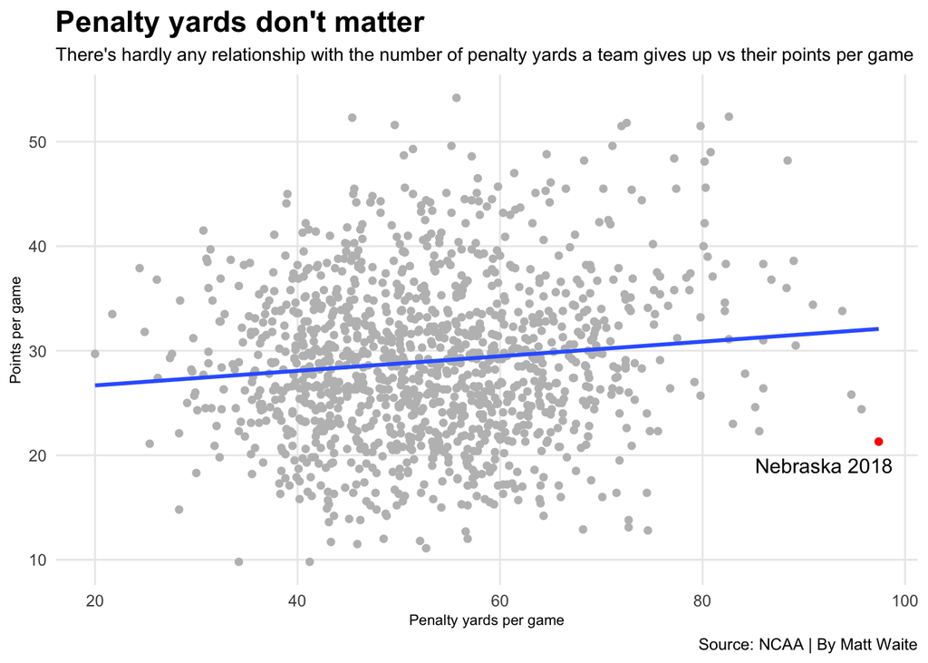

```r
ggplot(offensepenalties, aes(x=`Yards/G`, y=`Points/G`)) + geom_point(color="grey") + geom_smooth(method=lm, se=FALSE) + labs(x="Penalty yards per game", y="Points per game", title="Penalty yards don't matter", subtitle="There's hardly any relationship with the number of penalty yards a team gives up vs their points per game", caption="Source: NCAA | By Matt Waite") + theme_minimal() + theme(plot.title = element_text(size = 16, face = "bold"), axis.title = element_text(size = 8), plot.subtitle = element_text(size=10), panel.grid.minor = element_blank()) + geom_point(data=nupen, aes(x=`Yards/G`, y=`Points/G`), color="red") + geom_text(data=nupen, x=92, y=19, label="Nebraska 2018") + ggsave(filename="penaltyscatter.png", device = "png")
```

Now the linear model to put numbers to that chart showing how random it all is.

```r
penlm <- lm(offensepenalties$`Points/G` ~ offensepenalties$`Yards/G`)
summary(penlm)
```

```
##
## Call:
## lm(formula = offensepenalties$`Points/G` ~ offensepenalties$`Yards/G`)
##
## Residuals:
##      Min       1Q   Median       3Q      Max
## -18.3607  -5.0914  -0.2697   4.7259  25.0268
##
## Coefficients:
##                            Estimate Std. Error t value Pr(>|t|)
## (Intercept)                25.28406    0.96223  26.277  < 2e-16 ***
## offensepenalties$`Yards/G`  0.06982    0.01771   3.942 8.52e-05 ***
## ---
## Signif. codes:  0 '***' 0.001 '**' 0.01 '*' 0.05 '.' 0.1 ' ' 1
##
## Residual standard error: 7.504 on 1251 degrees of freedom
## Multiple R-squared:  0.01227,    Adjusted R-squared:  0.01148
## F-statistic: 15.54 on 1 and 1251 DF,  p-value: 8.52e-05
```

What’s interesting here? The p-value says that the correlation isn’t random – it’s real. It’s just meaningless.

### What matters? Third down.

Where the team is falling short, and where it actually matters, is on third down. First let’s get some third down data joined to scoring offense and then highlight Nebraska.

```r
offensethird <- left_join(offensivethirddowns, scoringoffense, by=c('Year', 'Name'))
```

```r
nuthird <- offensethird %>% filter(Name == "Nebraska")
```

This scatterplot and correlation will show a much tighter cluster of dots and a much more significant correlation.

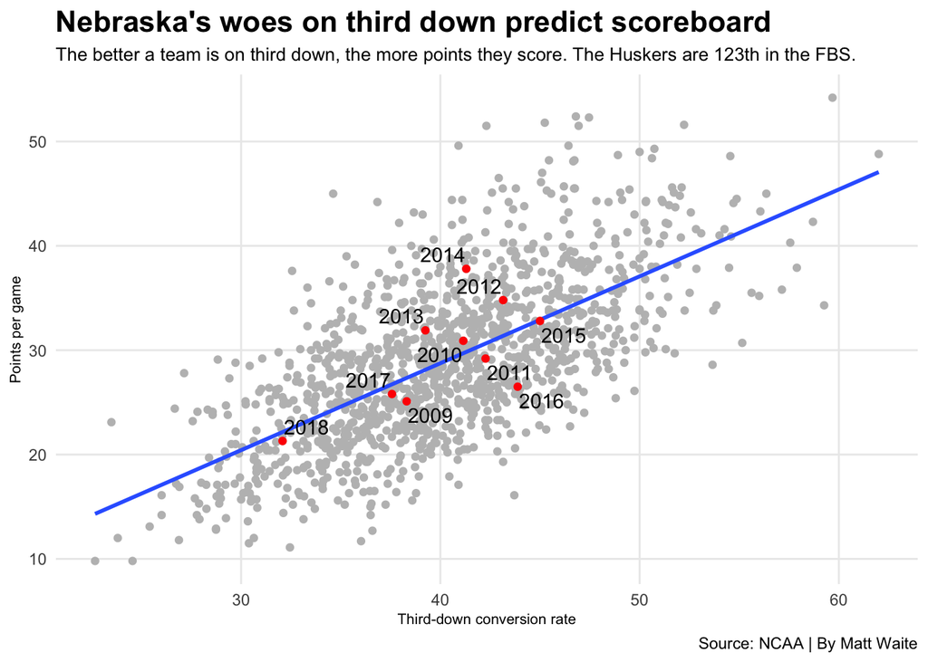

```r
ggplot(data=offensethird, aes(x=`Conversion %`, y=`Points/G`)) + geom_point(color="grey") + geom_smooth(method=lm, se=FALSE) + geom_point(data=nuthird, aes(x=`Conversion %`, y=`Points/G`), color="red") + geom_text_repel(data=nuthird, aes(x=`Conversion %`, y=`Points/G`, label=Year)) + labs(x="Third-down conversion rate", y="Points per game", title="Nebraska's woes on third down predict scoreboard", subtitle="The better a team is on third down, the more points they score. The Huskers are 123th in the FBS.", caption="Source: NCAA | By Matt Waite") + theme_minimal() + theme(plot.title = element_text(size = 16, face = "bold"), axis.title = element_text(size = 8), plot.subtitle = element_text(size=10), panel.grid.minor = element_blank()) + ggsave(filename="offensethirdscatter.png", device = "png")
```

```r
offlm <- lm(offensethird$`Points/G` ~ offensethird$`Conversion %`)
summary(offlm)
```

```
##
## Call:
## lm(formula = offensethird$`Points/G` ~ offensethird$`Conversion %`)
##
## Residuals:
##      Min       1Q   Median       3Q      Max
## -15.7386  -4.1415  -0.5442   3.5184  20.8273
##
## Coefficients:
##                             Estimate Std. Error t value Pr(>|t|)
## (Intercept)                 -4.56305    1.10029  -4.147 3.59e-05 ***
## offensethird$`Conversion %`  0.83280    0.02702  30.820  < 2e-16 ***
## ---
## Signif. codes:  0 '***' 0.001 '**' 0.01 '*' 0.05 '.' 0.1 ' ' 1
##
## Residual standard error: 5.692 on 1251 degrees of freedom
## Multiple R-squared:  0.4316, Adjusted R-squared:  0.4311
## F-statistic: 949.9 on 1 and 1251 DF,  p-value: < 2.2e-16
```

With this model, we can predict things. So here’s one game:

Nebraska converted on just 3 of 10 third downs against Wisconsin. Given that conversion percentage, our model says Nebraska should have scored 20.4 points. Wisconsin was better, converting 6 of 12. Our model says they should should have scored 37.1 points.

Final score: Wisconin 41, Nebraska 24.

### Snakebitten

Another area to look at is total yards per game versus points per game. This lends some credence to the penalty theory, except that stats say it’s wrong over time.

First going to grab the data.

```r
scoringoffense <- read_csv("~/Dropbox/SPMC350-Data-Literacy-and-Analytics-in-Sports/Data/ScoringOffense.csv")
totaloffense <- read_csv("~/Dropbox/SPMC350-Data-Literacy-and-Analytics-in-Sports/Data/TotalOffense.csv")
```

Now going to join it together.

```r
offense <- left_join(totaloffense, scoringoffense, by=c('Year', 'Name'))
```

And of course, pull out Nebraska.

```r
nu <- offense %>% filter(Name == "Nebraska") %>% filter(Year == 2018)
```

This scatterplot and correlation are much, much tigher than third down, but the real news here is Nebraska is a historic outlier.

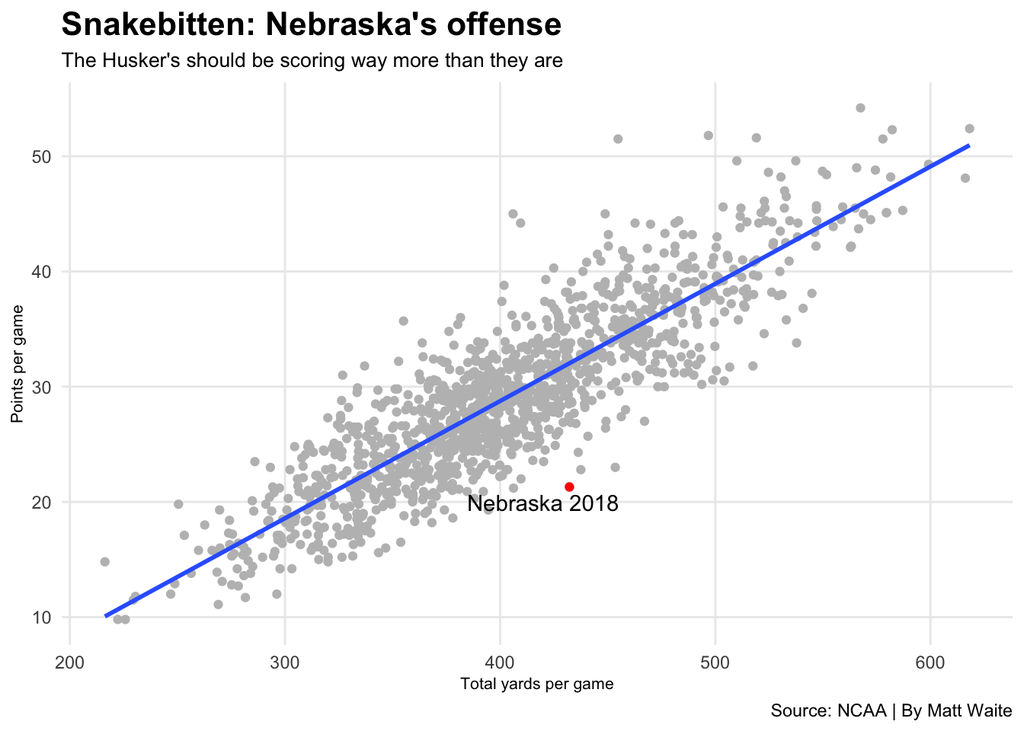

```r
ggplot(offense, aes(x=`Yards/G`, y=`Points/G`)) + geom_point(color="grey") + geom_smooth(method=lm, se=FALSE) + labs(x="Total yards per game", y="Points per game", title="Snakebitten: Nebraska's offense", subtitle="The Husker's should be scoring way more than they are", caption="Source: NCAA | By Matt Waite") + theme_minimal() + theme(plot.title = element_text(size = 16, face = "bold"), axis.title = element_text(size = 8), plot.subtitle = element_text(size=10), panel.grid.minor = element_blank()) + geom_point(data=nu, aes(x=`Yards/G`, y=`Points/G`), color="red") + geom_text_repel(data=nu, aes(x=`Yards/G`, y=`Points/G`, label="Nebraska 2018")) + ggsave(filename="yards.png", device = "png")
```

Here’s the correlation:

```r
cor.test(offense$`Yards/G`, offense$`Points/G`)
```

```
##
##  Pearson's product-moment correlation
##
## data:  offense$`Yards/G` and offense$`Points/G`
## t = 65.055, df = 1251, p-value < 2.2e-16
## alternative hypothesis: true correlation is not equal to 0
## 95 percent confidence interval:
##  0.8652656 0.8905958
## sample estimates:
##       cor
## 0.8785469
```

```r
offenselm <- lm(offense$`Points/G` ~ offense$`Yards/G`)
summary(offenselm)
```

```
##
## Call:
## lm(formula = offense$`Points/G` ~ offense$`Yards/G`)
##
## Residuals:
##      Min       1Q   Median       3Q      Max
## -11.1998  -2.3990  -0.1899   2.2981  17.1679
##
## Coefficients:
##                     Estimate Std. Error t value Pr(>|t|)
## (Intercept)       -11.951726   0.637449  -18.75   <2e-16 ***
## offense$`Yards/G`   0.101767   0.001564   65.06   <2e-16 ***
## ---
## Signif. codes:  0 '***' 0.001 '**' 0.01 '*' 0.05 '.' 0.1 ' ' 1
##
## Residual standard error: 3.606 on 1251 degrees of freedom
## Multiple R-squared:  0.7718, Adjusted R-squared:  0.7717
## F-statistic:  4232 on 1 and 1251 DF,  p-value: < 2.2e-16
```

If you apply that, you get that Nebraska should be scoring 32 points per game, 11 more than they were when this data was gathered.

```r
(432.2 * 0.101767) - 11.951726
```

```
## [1] 32.03197
```

### It’s not just the offense

But what about the defense?

Same story.

First we join the data and get Nebraska highlighted.

```r
defensethird <- left_join(defensivethirddowns, scoringdefense, by=c('Year', 'Name'))
nudefthird <- defensethird %>% filter(Name == "Nebraska")
```

Now the linear model.

```r
deflm <- lm(defensethird$`Points/G` ~ defensethird$`Conversion %`)
summary(deflm)
```

```
##
## Call:
## lm(formula = defensethird$`Points/G` ~ defensethird$`Conversion %`)
##
## Residuals:
##     Min      1Q  Median      3Q     Max
## -16.227  -3.744  -0.106   3.204  24.123
##
## Coefficients:
##                             Estimate Std. Error t value Pr(>|t|)
## (Intercept)                 -4.41092    1.04476  -4.222  2.6e-05 ***
## defensethird$`Conversion %`  0.80631    0.02636  30.592  < 2e-16 ***
## ---
## Signif. codes:  0 '***' 0.001 '**' 0.01 '*' 0.05 '.' 0.1 ' ' 1
##
## Residual standard error: 5.3 on 1251 degrees of freedom
## Multiple R-squared:  0.428,  Adjusted R-squared:  0.4275
## F-statistic: 935.9 on 1 and 1251 DF,  p-value: < 2.2e-16
```

Using the same basic linear model, we come up with very similar answers to the offense: for every third down conversion percentage point surrendered, the opponent scores .8 points.

Get off the field on third down, keep the other team from scoring. Here’s the scatterplot with Nebraska’s teams highlighted.

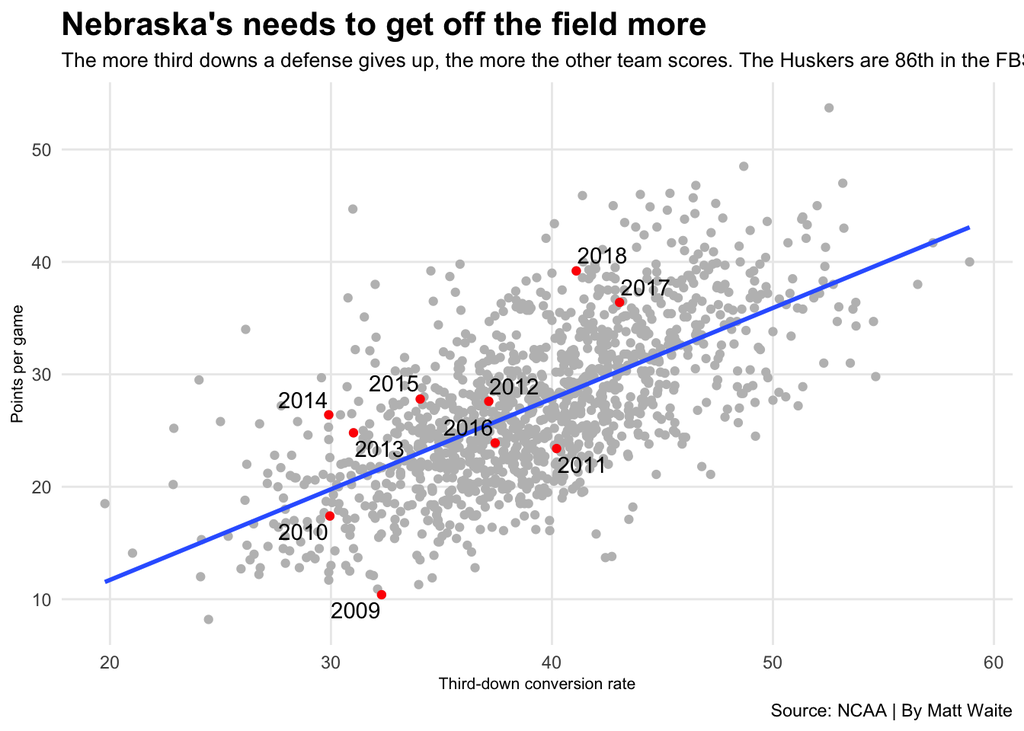

```r
ggplot(data=defensethird, aes(x=`Conversion %`, y=`Points/G`)) + geom_point(color="grey") + geom_smooth(method=lm, se=FALSE) + geom_point(data=nudefthird, aes(x=`Conversion %`, y=`Points/G`), color="red") + geom_text_repel(data=nudefthird, aes(x=`Conversion %`, y=`Points/G`, label=Year)) + labs(x="Third-down conversion rate", y="Points per game", title="Nebraska's needs to get off the field more", subtitle="The more third downs a defense gives up, the more the other team scores. The Huskers are 86th in the FBS.", caption="Source: NCAA | By Matt Waite") + theme_minimal() + theme(plot.title = element_text(size = 16, face = "bold"), axis.title = element_text(size = 8), plot.subtitle = element_text(size=10), panel.grid.minor = element_blank()) + ggsave(filename="defensethirdscatter.png", device = "png")
```

Nebraska’s best defenses since 2009 – including the 2009 defense that was one of the best in school history – have all been stingy on third down. That 2009 defense allowed only 10.4 points per game – best in the FBS. It allowed opponents to convert on 32 percent of third downs – which means they overperformed the model by quite a ways. The 2010 defense fit much closer to the model but still overperformed – it allowed only 30 percent of third downs to convert, and gave up just 17.4 points per game.

So for Nebraska to win, the numbers say little else matters more than getting better on third down.